# Tidybiology Final Project

Telmo Llanga

October 21, 2019

### Import Datasets

Proteins and Genes were datasets included in the tidybiology package, proteins_genes_inner was created with an `inner_join` function which joined them both together.

```r
data(proteins)
data(genes)
proteins_genes_inner <- inner_join(proteins, genes, by = "gene_name")
```

### Take a `glimpse` into the data in the dataframe

The proteins_genes_inner dataset includes not only protein coding genes but also pseudogenes and other chromosomal gene like elements. In total it has 17 variables (columns), and 20038 observations.

```r
glimpse(proteins_genes_inner)
```

```
## Observations: 20,038
## Variables: 17
## $ uniprot_id               <chr> "P04217", "Q9NQ94", "P01023", "A8K2U0",…
## $ gene_name                <chr> "A1BG", "A1CF", "A2M", "A2ML1", "A3GALT…
## $ gene_name_alt            <chr> NA, "ACF ASP", "CPAMD5 FWP007", "CPAMD9…
## $ protein_name             <chr> "Alpha-1B-glycoprotein ", "APOBEC1 comp…
## $ protein_name_alt         <chr> "Alpha-1-B glycoprotein)", "APOBEC1-sti…
## $ sequence                 <chr> "MSMLVVFLLLWGVTWGPVTEAAIFYETQPSLWAESESL…
## $ length                   <dbl> 495, 594, 1474, 1454, 340, 353, 340, 54…
## $ mass                     <dbl> 54254, 65202, 163291, 161107, 38754, 40…
## $ gene_description         <chr> "alpha-1-B glycoprotein", "APOBEC1 comp…
## $ chromosome_scaffold_name <chr> "19", "10", "12", "12", "1", "22", "3",…
## $ strand                   <dbl> -1, -1, -1, 1, -1, -1, -1, -1, 1, 1, 1,…
## $ transcript_start_bp      <dbl> 58345178, 50799409, 9067664, 8822621, 3…
## $ transcript_end_bp        <dbl> 58347634, 50885675, 9091412, 8876787, 3…
## $ transcript_length        <dbl> 2134, 9221, 600, 5127, 1023, 2092, 1779…
## $ gene_percent_gc_content  <dbl> 55.80, 36.24, 37.18, 44.23, 54.19, 52.3…
## $ gene_stable_id           <chr> "ENSG00000121410", "ENSG00000148584", "…
## $ transcript_stable_id     <chr> "ENST00000596924", "ENST00000374001", "…
```

## Exploratory Data Analysis

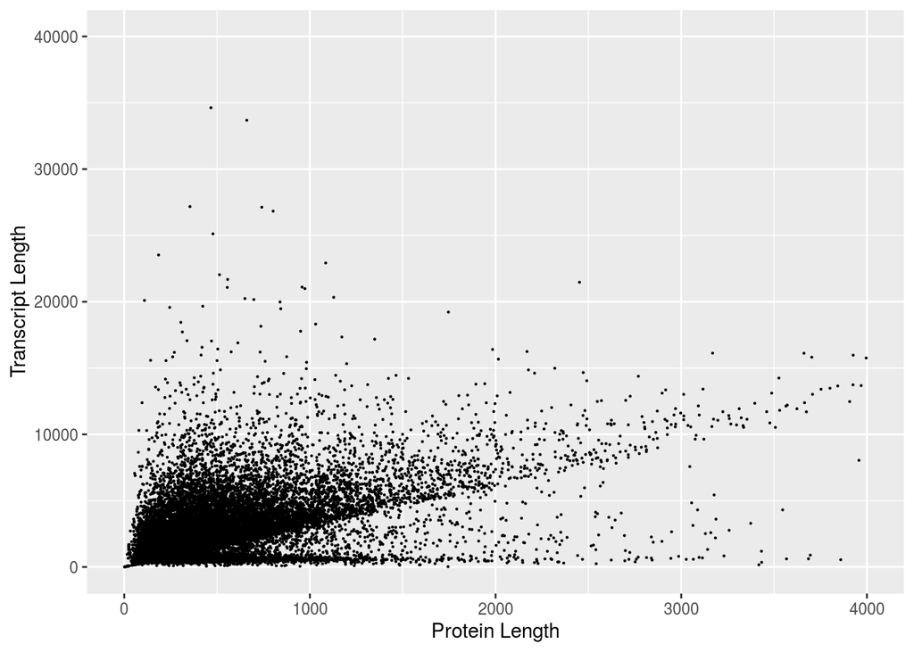

```r
#Interested in looking at the relationship between transcript length and protein length we plotted these variables on a graph

ggplot(proteins_genes_inner, aes(length,transcript_length)) + geom_point(size=0.1) + xlim(0,4000)+ ylim(0,40000) + labs(x="Protein Length", y="Transcript Length")
```

```r
#To furhter explore these relationships we took a ratio of these variables to compare to other variables using the `mutate()`

proteins_genes_inner2<-mutate(proteins_genes_inner, Translated_ratio = (transcript_length/length))
```

### Some Data Cleaning

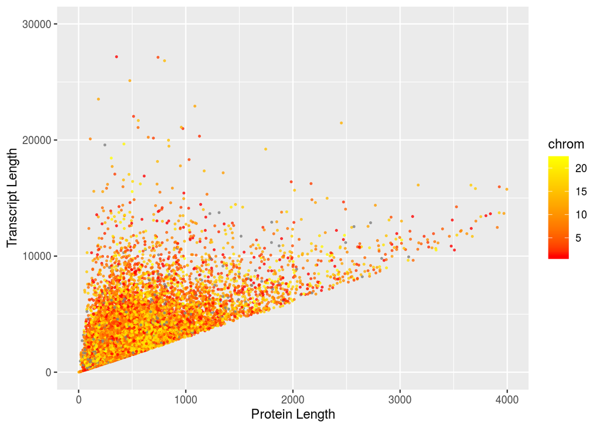

```r
#We used filter >3 to attempt some data cleaning based on the principle that it takes 3 nucleotides to encode for a single amino acid.

proteins_genes_inner3<-filter(proteins_genes_inner2, Translated_ratio > 3)


proteins_genes_inner4<-separate(proteins_genes_inner3, chromosome_scaffold_name,
                c("chrom", "Scaffold1","Scaffold2","Scaffold3"))

proteins_genes_inner4$chrom <- as.numeric(as.character(proteins_genes_inner4$chrom))

#We then go ahead and re-plot to visualize our data cleaning and to see if we can visualize any obvious chromosomal trends

ggplot(proteins_genes_inner4, aes(length,transcript_length, color= chrom)) + geom_point(size=0.5, alpha=0.7) + xlim(0,4000)+ ylim(0,30000)+ labs(x="Protein Length", y="Transcript Length")+scale_color_gradient(low="red", high="yellow")
```

### New Variables, New Graphs

We wanted to make more informative graphs, so in order to do this we binned data into groups using the `cut()` function to be further analyzed

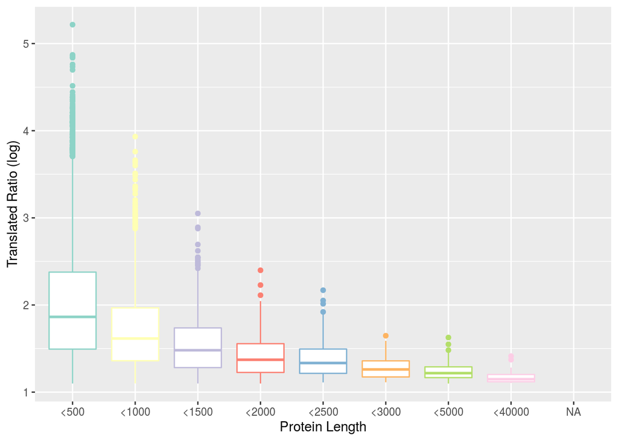

```r
#We add new variables Ratio_bins and Length_bins

proteins_genes_inner3$Ratio_bins<-cut(proteins_genes_inner3$Translated_ratio, c(0,5,10,15,20,25,30))

proteins_genes_inner3$Length_bins<-cut(proteins_genes_inner3$length, c(3,500,1000,1500,2000,2500,3000,5000,20000), labels = c("<500","<1000","<1500","<2000","<2500","<3000","<5000","<40000"), right = TRUE)

#We analyzed the Translated Ratio compared to protein lenght in a boxplot

ggplot(proteins_genes_inner3) + geom_boxplot(aes(Length_bins,log(Translated_ratio), color=Length_bins)) + labs(x="Protein Length", y="Translated Ratio (log)") + guides(color = "none") + scale_color_brewer(palette="Set3")
```

### More data cleaning, and a final graph

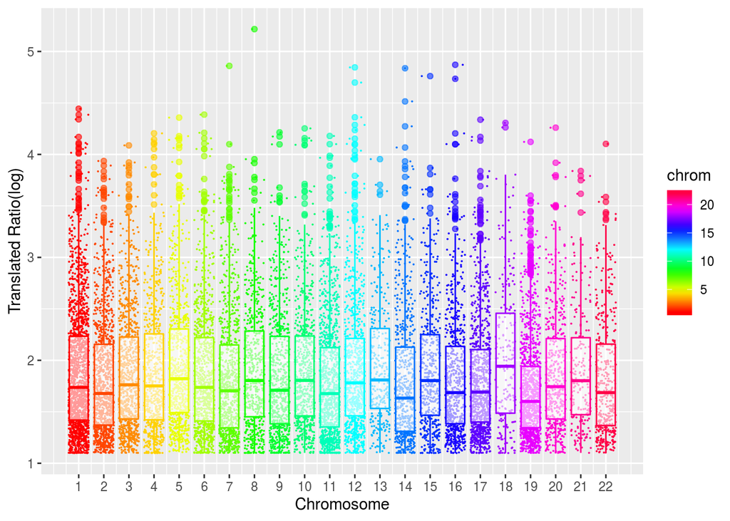

```r
#Looking to explore if any particular somatic chromosomes have different ratios of translated protein to transcript lengths, we first needed to split the chromosome_scaffold name data column to obtain individual chromosomes and for this we use the separate() function.

  proteins_genes_inner4<-separate(proteins_genes_inner3, chromosome_scaffold_name,
                c("chrom", "second","Scaffold","Scaffold_cont","Scaffold_cont2","Scaffold_cont3"))

#We needed to further clean this data as it had some data types which made it difficult to plot, therefore we kept only numeric values by assigning N.A values to non-numeric values using the as.numeric() function.

proteins_genes_inner4$chrom <- as.numeric(as.character(proteins_genes_inner4$chrom))

#We then went ahead and plotted Translated_ratio relative to chromosome groups, and we see they are very similar to each other.

ggplot(proteins_genes_inner4, aes(chrom,log(Translated_ratio), group=chrom,color=chrom))+geom_jitter(size=0.01) + geom_boxplot(alpha=0.6 )+scale_color_gradientn(colours = rainbow(22))+labs(x="Chromosome",y="Translated Ratio(log)") +
  scale_x_continuous(labels = c(1,2,3,4,5,6,7,8,9,10,11,12,13,14,15,16,17,18,19,20,21,22), breaks = c(1,2,3,4,5,6,7,8,9,10,11,12,13,14,15,16,17,18,19,20,21,22))
```

```r
ggsave("image.png")
```

### Final Statistics

To explore the more promising of our data exploratory graphs relating Translated_ratio to protein length, I went ahead and got some final statistics with more data-permisive non-parametric tests

```r
kruskal.test(Translated_ratio ~ Length_bins, data = proteins_genes_inner3)
```

```
##
##  Kruskal-Wallis rank sum test
##
## data:  Translated_ratio by Length_bins
## Kruskal-Wallis chi-squared = 1644.1, df = 7, p-value < 2.2e-16
```

With a statistical difference between groups by a Krustal Wallis test, a comparison between all groups by a pairwise wilcox statistical test can narrow down if there are statistical differences between particular groups

```r
pairwise.wilcox.test(proteins_genes_inner3$Translated_ratio, proteins_genes_inner3$Length_bins,
                 p.adjust.method = "BH")
```

```
##
##  Pairwise comparisons using Wilcoxon rank sum test
##
## data:  proteins_genes_inner3$Translated_ratio and proteins_genes_inner3$Length_bins
##
##        <500    <1000   <1500   <2000   <2500   <3000   <5000
## <1000  < 2e-16 -       -       -       -       -       -
## <1500  < 2e-16 < 2e-16 -       -       -       -       -
## <2000  < 2e-16 < 2e-16 8.7e-11 -       -       -       -
## <2500  < 2e-16 < 2e-16 4.3e-08 0.26941 -       -       -
## <3000  < 2e-16 < 2e-16 4.1e-13 3.4e-05 0.00288 -       -
## <5000  < 2e-16 < 2e-16 < 2e-16 2.1e-09 2.0e-06 0.10867 -
## <40000 2.0e-11 4.1e-11 6.7e-10 2.7e-07 5.5e-07 0.00035 0.00188
##
## P value adjustment method: BH
```

We see a significant difference between smaller and larger protein groupings

## Conclusions

While we see no difference by chromosome, there seems to be a strong correlation of translated length to protein size. Further correlating these results to gene subsets and their genomic coordinate distribution along chromosomes may be of basic understanding of genome evolution.

## Prioritized follow-up studies

Repeat analysis with a dataset with the same variables to verify correlations.

Further correlating these results to genomic coordinate distribution along chromosomes.

Analyzing subsets of genes relative to their location

Carry out similar analysis with a dataset of experimentally verified promoter regions

## Acknolwedgements

I would like to acknowledge our instructors for making this knowledge structured and accesible and everyone who has put together this technology platform to analyze data in an organized reproducible manner.